# 3dasm_Lecture4 slides

[figure not shown]

## Data-driven Design and Analyses of Structures and Materials (3dasm)

## Lecture 4

### Miguel A. Bessa | M.A.Bessa@tudelft.nl | Associate Professor

## **OPTION 1**. Run this notebook **locally in your computer**:

1. Confirm that you have the 3dasm conda environment (see Lecture 1).
2. Go to the 3dasm_course folder in your computer and pull the last updates of the [repository](https://github.com/bessagroup/3dasm_course):

   ```
   git pull
   ```

3. Open command window and load jupyter notebook (it will open in your internet browser):

   ```
   conda activate 3dasm
   jupyter notebook
   ```

4. Open notebook of this Lecture.

## **OPTION 2**. Use **Google's Colab** (no installation required, but times out if idle):

1. go to https://colab.research.google.com
2. login
3. File > Open notebook
4. click on Github (no need to login or authorize anything)
5. paste the git link: https://github.com/bessagroup/3dasm_course
6. click search and then click on the notebook for this Lecture.

## Outline for today

- Probability: multivariate models
  - The multivariate Gaussian: joint pdf, conditional pdf and marginal pdf
  - Covariance and covariance matrix

**Reading material**: This notebook (+ Bishop's book Section 2.3)

## Summary of Bayes' rule

$\require{color}$ $$ {\color{green}p(z|y=\mathcal{D}_y)} = \frac{ {\color{blue}p(y=\mathcal{D}_y|z)}{\color{red}p(z)} } {p(y=\mathcal{D}_y)} = \frac{ {\color{magenta}p(y=\mathcal{D}_y, z)} } {p(y=\mathcal{D}_y)} $$

- ${\color{red}p(z)}$ is the **prior** distribution
- ${\color{blue}p(y=\mathcal{D}_y|z)}$ is the **likelihood** function
- ${\color{magenta}p(y=\mathcal{D}_y, z)}$ is the **joint likelihood** (product of likelihood function with prior distribution)
- $p(y=\mathcal{D}_y)$ is the **marginal likelihood**
- ${\color{green}p(z|y=\mathcal{D}_y)}$ is the **posterior**

We can write Bayes' rule as posterior $\propto$ likelihood $\times$ prior , where we are ignoring the denominator $p(y=\mathcal{D}_y)$ because it is just a **constant** independent of the hidden variable $z$.

## Diving deeper into the joint pdf

Later we will dedicate a lot of effort to using Bayes' rule to update a distribution over unknown values of some quantity of interest, given relevant observed data $\mathcal{D}_y$.

This is what is called *Bayesian inference* (a.k.a. *posterior inference*).

- But before we do that, we need to understand very well multivariate pdfs.
  - In particular, let's focus on the most important one: the **multivariate Gaussian**

## Multivariate Gaussian pdf (a.k.a. MVN distribution)

where $\boldsymbol{\mu}=\mathbb{E}[\mathbf{x}]\in \mathbb{R}^D$ is the mean vector, and $\boldsymbol{\Sigma}= \text{Cov}[\mathbf{x}]$ is the $D\times D$ **covariance matrix**.

### Covariance matrix

The covariance matrix is a natural generalization of the variance (Lecture 1) for the multivariate case!

$$ \begin{align} \boldsymbol{\Sigma} = \text{Cov}[\mathbf{x}] &= \mathbb{E}\left[(\mathbf{x}-\mathbb{E}[\mathbf{x}])(\mathbf{x}-\mathbb{E}[\mathbf{x}])^T \right] \\ &= \begin{bmatrix} \mathbb{V}[x_1] & \text{Cov}[x_1,x_2] & \cdots & \text{Cov}[x_1, x_D] \\ \text{Cov}[x_2,x_1] & \mathbb{V}[x_2] & \cdots & \text{Cov}[x_2, x_D] \\ \vdots & \vdots & \ddots & \vdots \\ \text{Cov}[x_D,x_1] & \text{Cov}[x_D,x_2] & \cdots & \mathbb{V}[x_D] \\ \end{bmatrix} \end{align} $$

where $\text{Cov}[x_i,x_j] = \mathbb{E}\left[(x_i-\mathbb{E}[x_i])(x_j-\mathbb{E}[x_j])\right] = \mathbb{E}[x_i x_j] - \mathbb{E}[x_i]\mathbb{E}[x_j]$

Also note that $\mathbb{V}[x_i]=\text{Cov}[x_i,x_i]$.

#### Notes about covariance and normalized covariance (correlation coefficient)

The covariance between two rv's $y$ and $z$ measures the degree to which $y$ and $z$ are **linearly** related.

Covariances can be between negative and positive infinity.

Sometimes it is more convenient to work with a normalized measure, with a finite lower and upper bound. The (Pearson) **correlation coefficient** between $y$ and $z$ is defined as

$$ \rho = \text{corr}[y,z] = \frac{\text{Cov}[y,z]}{\sqrt{\mathbb{V}[y]\mathbb{V}[z]}} $$

Covariance and correlation coefficient measure the same relationship.

#### Note about normalized covariance (correlation coefficient)

Several sets of $(y_i, z_i)$ points, with the correlation coefficient of $y$ and $z$ for each set.

[figure not shown]

Top row: $\text{corr}[y,z]$ reflects the noisiness and direction of a linear relationship.

Middle row: $\text{corr}[y,z]$ **does not** reflect the slope of that relationship

Bottom row: $\text{corr}[y,z]$ **does not** reflect many aspects of nonlinear relationships.

(Additional note: the figure in the center has a slope of 0 but in that case the correlation coefficient is undefined because the variance of $z$ is zero.)

## Understanding the MVN pdf (a common joint pdf)

$$ \begin{align} p(\mathbf{x}|\boldsymbol{\mu},\boldsymbol{\Sigma}) & = \frac{e^{-\frac{1}{2}(\mathbf{x}-\boldsymbol{\mu})^T\boldsymbol{\Sigma}^{-1}(x-\mu)}}{\sqrt{(2\pi)^D |\boldsymbol{\Sigma}|}} \\ & = \frac{1}{(2\pi)^{D/2} |\boldsymbol{\Sigma}|^{1/2}} \exp\left[ -\frac{1}{2}(\mathbf{x}-\boldsymbol{\mu})^T\boldsymbol{\Sigma}^{-1}(\mathbf{x}-\boldsymbol{\mu})\right] \end{align} $$

where $\boldsymbol{\mu}=\mathbb{E}[\mathbf{x}]\in \mathbb{R}^D$ is the mean vector, and $\boldsymbol{\Sigma}= \text{Cov}[\mathbf{x}]$ is the $D\times D$ **covariance matrix**.

- Multivariate Gaussian pdf's are very important in ML and Statistics.
- Let's discover their properties by working out some examples.

### Exercise 1: MVN from independent Gaussian rv's

Consider two **independent** rv's $x_1$ and $x_2$ where each of them is a univariate Gaussian pdf:

$$ x_1 = \mathcal{N}(x_1|\mu_{x_1}, \sigma_{x_1}^2) $$$$ x_2 = \mathcal{N}(x_2|\mu_{x_2}, \sigma_{x_2}^2) $$

where $\mu_{x_1}=10$, $\sigma_{x_1}^2=5^2$, $\mu_{x_2}=0.5$ and $\sigma_{x_2}^2=2^2$.

Answer the following questions:

1. What is the joint pdf $p(x_1, x_2)$?
2. Calculate the covariance matrix for $\mathbf{x}=\begin{bmatrix}x_1\\x_2\end{bmatrix}$.

Once you finish, let's plot the joint pdf.

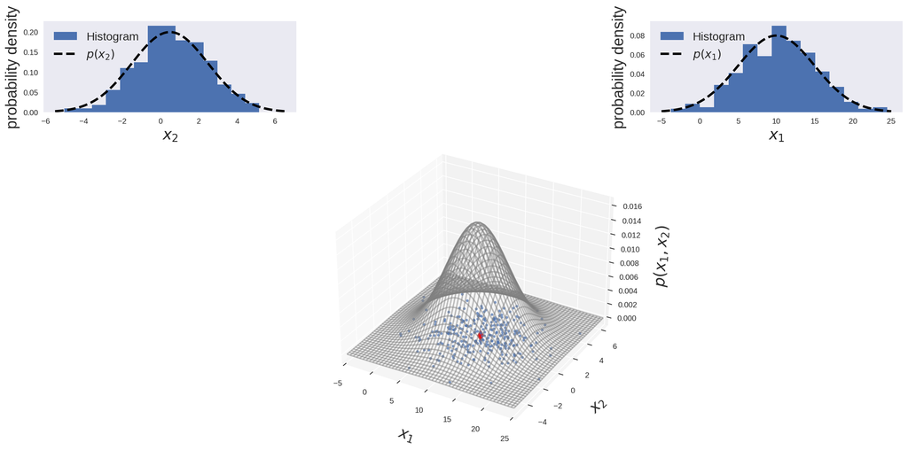

```python
# HIGHLIGHT DIFFERENCE IN MAXIMUM PROBABILITY DENSITIES!!
fig_joint_pdf_ex1 # The joint pdf results from the multiplication...
```

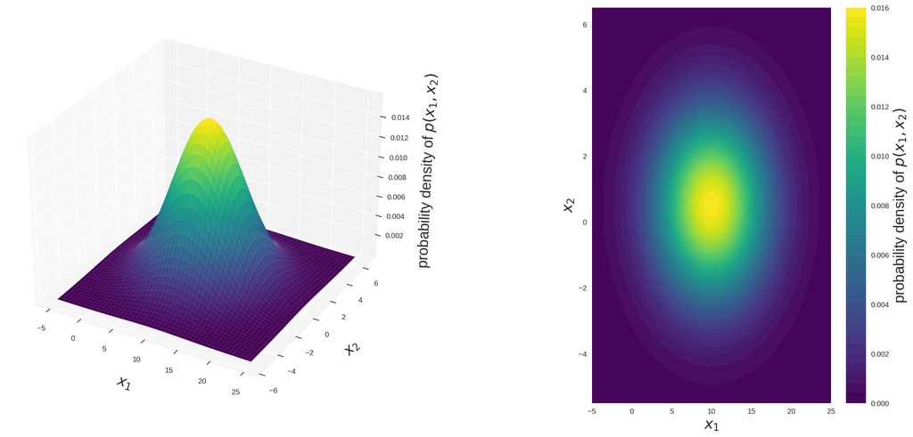

```python
# Same pdf but now as a surface plot and as a contour plot.
fig_joint_pdf_ex1_color
```

## Car stopping distance problem (I know how much you missed it!)

Back to our simple car stopping distance problem with constant velocity $x=75$ m/s.

We have two rv's for this problem,

$$ \mathbf{x}=\begin{bmatrix} x_1 \\ x_2 \end{bmatrix}= \begin{bmatrix} y \\ z \end{bmatrix} $$

- Note: this $\mathbf{x}$ has NOTHING to do with our velocity variable $x$. Be careful!

$$ \begin{align} \boldsymbol{\Sigma} = \text{Cov}[\mathbf{x}] &= \mathbb{E}\left[(\mathbf{x}-\mathbb{E}[\mathbf{x}])(\mathbf{x}-\mathbb{E}[\mathbf{x}])^T \right] \\ &= \begin{bmatrix} \mathbb{V}[y] & \text{Cov}[y,z] \\ \text{Cov}[z,y] & \mathbb{V}[z] \end{bmatrix} \end{align} $$

where $\text{Cov}[y,z] = \mathbb{E}\left[(y-\mathbb{E}[y])(z-\mathbb{E}[z])\right] = \mathbb{E}[y z] - \mathbb{E}[y]\mathbb{E}[z]$

### Exercise 2: Covariance matrix for the car problem when $x=75$ m/s

1. Calculate the mean vector and covariance matrix values for our problem (with $x=75$ m/s). **Be careful** that $y$ is dependent on $z$!
2. Calculate the determinant of the covariance matrix.

Once you are done, let's plot the multivariate Gaussian $p(y,z)$ obtained from the mean vector and covariance matrix you calculated.

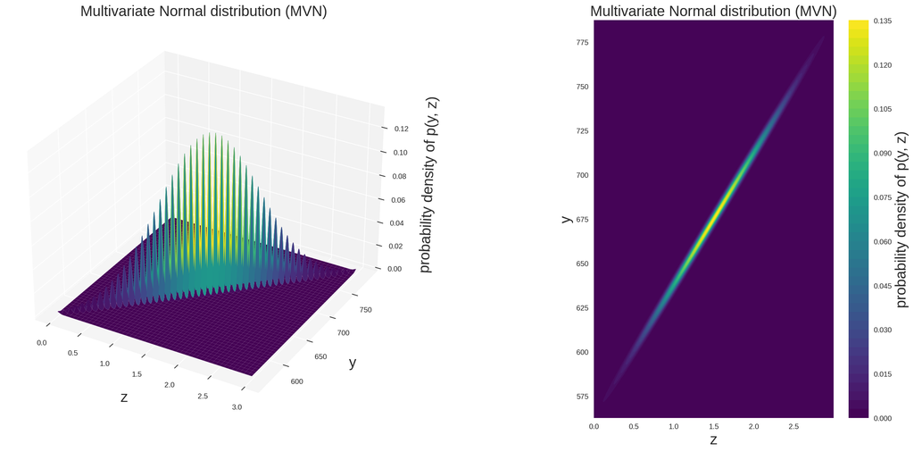

```python
# Code to generate this figure is hidden in presentation (shown in notes)
regularizer = 1e-3 # Thikhonov regularization to approximate p(y,z) for car stopping distance problem
plot_car_MVN_regularized(regularizer) # SHOW WHAT HAPPENS IF regularizer is 0, 0.1 and 1e-3
```

### Recal the joint pdf $p(y,z)$ we found for this problem in Lecture 3!

We determined in Lecture 3 that the joint pdf $p(y,z)$ for this problem is

$$ p(y, z) = \delta\left(y-(z x+0.1x^2)\right) p(z) $$

where $p(z) = \mathcal{N}(\mu_z=1.5,\sigma_z^2=0.5^2)$, and $p(y|z)=\delta\left(y-(z x+0.1x^2)\right)$ is the Dirac delta pdf that assigns zero probability everywhere except when $y=z x+0.1x^2$.

- Now we see how to approximate this pdf for plotting it:
  - We can consider that the joint pdf $p(y,z)$ is an MVN, and include a small term in the diagonal of the Covariance matrix to plot it! As this term tends to zero, we retrieve the Dirac delta effect.

### A slightly more complicated car stopping distance problem

[figure not shown]

Let's focus (again) on our favorite problem, but this time we include two rv's $z_1$ and $z_2$ in the governing model:

$\require{color}{\color{red}y} = {\color{blue}z_1}\cdot x + {\color{magenta}z_2}\cdot x^2$

where we will assume as before that $z_1 \sim \mathcal{N}(\mu_{z_1}=1.5,\sigma_{z_1}^2=0.5^2)$, but now we assume $z_2 \sim \mathcal{N}(\mu_{z_2}=0.1,\sigma_{z_2}^2=0.01^2)$. Recall that in previous lectures we assumed $z_2=0.1$.

## A slightly more complicated car stopping distance problem

[figure not shown]

For simplicity, also consider that every driver is going at the same velocity $x=75$ m/s.

$\require{color}{\color{red}y} = {\color{blue}z_1}\cdot 75 + {\color{magenta}z_2}\cdot 75^2 = 75 {\color{blue}z_1} + 5625 {\color{magenta}z_2}$

where $z_1 \sim \mathcal{N}(\mu_{z_1}=1.5,\sigma_{z_1}^2=0.5^2)$, and $z_2 \sim \mathcal{N}(\mu_{z_2}=0.1,\sigma_{z_2}^2=0.01^2)$.

# HOMEWORK

For the slightly more complicated car stopping distance problem, answer this:

1. Show that the conditional pdf $p(y|z_1)$ is:

$$ p(y|z_1) = \mathcal{N}\left(y | \mu_{y|z_1}=5625\mu_{z_2}+75z_1, \sigma_{y|z_1}^2=(5625\sigma_{z_2})^2\right) $$

1. What is the joint pdf $p(y,z_1)$?
2. Calculate the covariance matrix for $\mathbf{x}=\begin{bmatrix}y\\z_1\end{bmatrix}$, i.e. $\text{Cov}\left(\begin{bmatrix}y\\z_1\end{bmatrix}\right)$

The next cell includes the plots of $p(y|z_1)$, $p(y,z_1)$. **But do your HOMEWORK!**

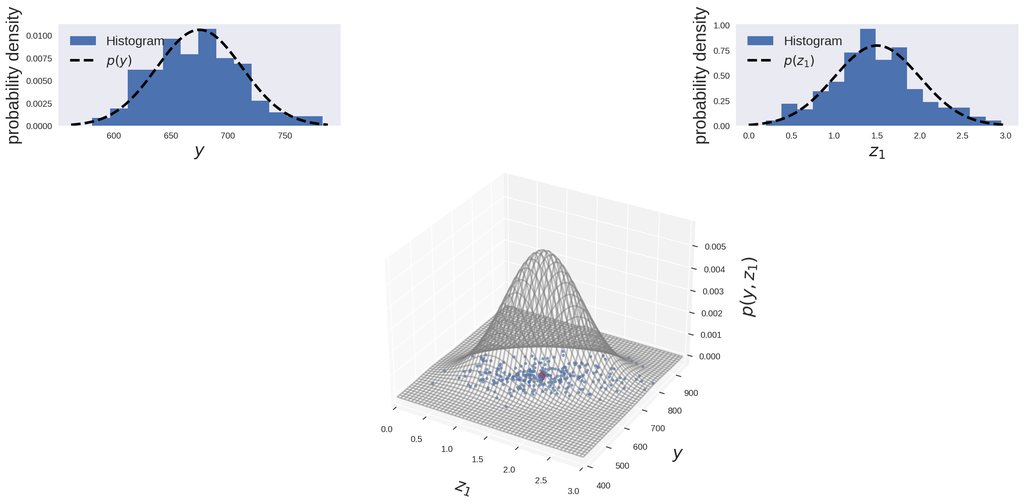

```python
# HIGHLIGHT DIFFERENCE IN MAXIMUM PROBABILITY DENSITIES!!
fig_joint_pdf_HW # The joint pdf results from the multiplication...
```

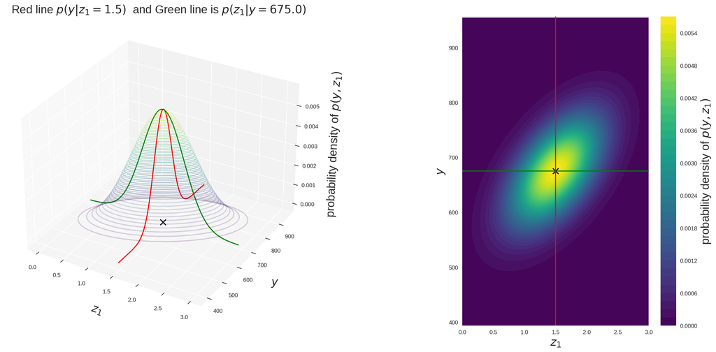

```python
# Static plot (I skip this cell in presentations, but use it when printing slides to PDF)
fig2_joint_pdf_HW(y_value=mu_y,z1_value=mu_z1)
```

## Conclusions about Gaussian distributions

Our empirical investigations in this Lecture, have led to some interesting observations! They can be generalized to:

- If two sets of variables are jointly Gaussian, i.e. if their joint pdf is an MVN, then:
  - their conditional pdfs are Gaussian, i.e. the conditional distribution of one set conditioned on the other is again Gaussian!
  - the marginal distribution of either set is also Gaussian!

This is really important because it means that Gaussians are closed under Bayesian conditioning! We will explore this later.

- Note: Bishop's book has a fantastic discussion about the univariate and multivariate Gaussian distribution (Section 2.3). **I recommend reading it.** I included it in the notes below this cell.

## Summary of partitioned Gaussians

Given a joint Gaussian pdf $p(\mathbf{x})=\mathcal{N}(\mathbf{x}|\boldsymbol{\mu},\boldsymbol{\Sigma})$ with $\boldsymbol{\Lambda}\equiv\boldsymbol{\Sigma}^{-1}$ and

$$ \mathbf{x}=\begin{bmatrix} \mathbf{x}_a \\ \mathbf{x}_b \end{bmatrix}, \quad \boldsymbol{\mu} = \begin{bmatrix} \boldsymbol{\mu}_a \\ \boldsymbol{\mu}_b \end{bmatrix}, \quad \boldsymbol{\Sigma} = \begin{bmatrix} \boldsymbol{\Sigma}_{aa} & \boldsymbol{\Sigma}_{ab} \\ \boldsymbol{\Sigma}_{ba} & \boldsymbol{\Sigma}_{bb} \end{bmatrix}, \quad \boldsymbol{\Lambda} = \begin{bmatrix} \boldsymbol{\Lambda}_{aa} & \boldsymbol{\Lambda}_{ab} \\ \boldsymbol{\Lambda}_{ba} & \boldsymbol{\Lambda}_{bb} \end{bmatrix} $$

We have the conditional distribution $p(\mathbf{x}_a,\mathbf{x}_b) = \mathcal{N}(\mathbf{x}_a|\boldsymbol{\mu}_{a|b}, \boldsymbol{\Lambda}_{aa}^{-1})$ with the following parameters:

$$ {\color{blue}\boldsymbol{\mu}_{a|b} = \boldsymbol{\mu}_a-\boldsymbol{\Lambda}_{aa}^{-1}\boldsymbol{\Lambda}_{ab}(\mathbf{x}_b-\boldsymbol{\mu}_b)} $$$$\require{color}{\color{red} \boldsymbol{\Sigma}_{a|b} = \boldsymbol{\Lambda}_{aa}^{-1}} $$

The marginal distribution is $p(\mathbf{x}_a) = \mathcal{N}(\mathbf{x}_a|\boldsymbol{\mu}_a, \boldsymbol{\Sigma}_{aa})$.

### See you next class

Have fun!